# Reproduce Me

Your Name

Last compiled: Feb 13, 2017

# 1 Directions

Reproduce this document. The data frame `WATER` is from the `PASWR2` package written by Arnholt (2016). The example is from Ugarte, Militino, and Arnholt (2015).

## 1.1 Example Problem 9.12

A bottled water company acquires its water from two independent sources, `x` and `y`. The company suspects that the sodium content in the water from source `x` is less than the sodium content for water from source `y`. An independent agency measures the sodium content in 20 samples from source `x` and 10 samples from source `y` and stores them in the data frame `WATER`. Is there statistical evidence to suggest the average sodium content in the water from source `x` is less than the average sodium content in the water from source `y`? The measurements for the sodium values are mg/L. Use an $\alpha$ of 0.05 to test the appropriate hypotheses.

## 1.2 Partial Solution

To solve this problem, start by verifying the reasonableness of the normality assumption. The side-by-side boxplots and normal quantile-quantile plots depicted in Figures 1.1 and 1.2, respectively suggest it is reasonable to assume the sodium values for both sources follow normal distributions; however, it is clear from the boxplots that the variances are very different.

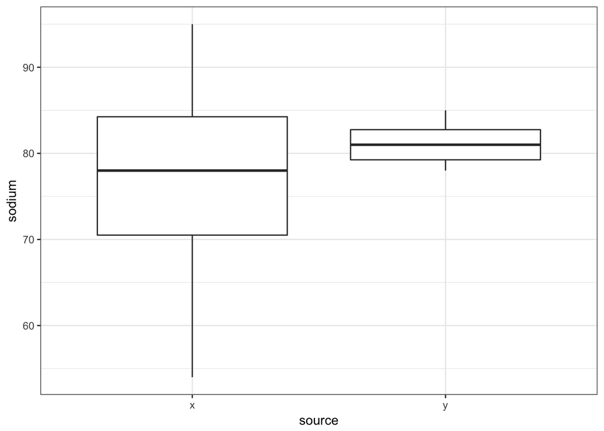

Figure 1.1: Side-by-side boxplots of the sodium content for source `x` and `y`

```r
library(PASWR2)
ggplot(data = WATER, mapping = aes(x = source, y = sodium)) +
  geom_boxplot() +
  theme_bw()
```

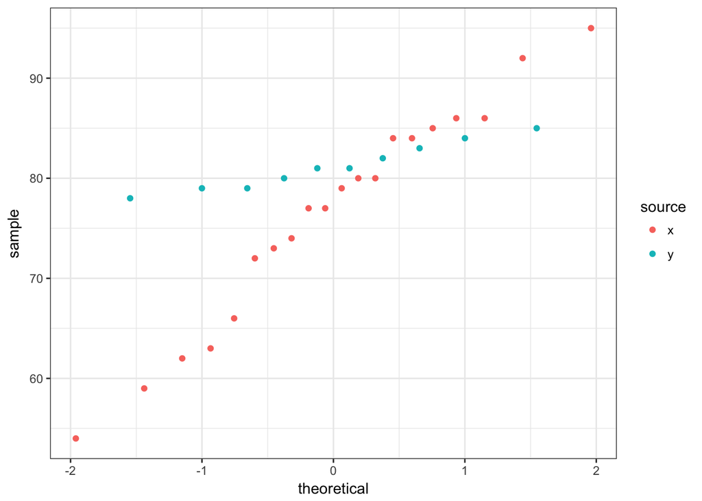

Figure 1.2: Normal quantile-quantile plots of the sodium content for source `x` and source`y`

```r
ggplot(data = WATER, mapping = aes(sample = sodium, color = source)) +
  stat_qq() +
  theme_bw()
```

Step 1: **Hypotheses** — Since the problem wants to test to see if the mean sodium content from source `x` is less than the mean sodium content from source `y`, use a lower one-sided alternative hypothesis as shown in Equation (1.1).

$$\begin{align}
H_0&: \mu_x - \mu_y = 0 \nonumber \\
H_A&: \mu_x - \mu_y < 0.
\tag{1.1}
\end{align}$$

```r
library(dplyr)
NDF <- WATER %>%
  group_by(source) %>%
  summarize(MEAN = mean(sodium), SD = sd(sodium), n = n())
knitr::kable(NDF, caption = "Summary statistics for the `WATER` data frame")
```

Table 1.1: Summary statistics for the `WATER` data frame

| source | MEAN | SD | n |
| --- | --- | --- | --- |
| x | 76.4 | 11.080566 | 20 |
| y | 81.2 | 2.299758 | 10 |

Step 2: **Test Statistic** — The test statistic chosen is $\bar{X} - \bar{Y}$ because $E\left[\bar{X} - \bar{Y} \right] = \mu_x - \mu_y$. The value of this test statistic is $76.4 - 81.2 = -4.8$. The standardized test statistic under the assumption theat $H_0$ is true and its appropriate distribution are given in Equation (1.2).

$$\begin{equation}
\frac{\left[(\bar{X} - \bar{Y}) - \delta_0 \right]}{\sqrt{\left(\frac{S_x^2}{n_x} + \frac{S_y^2}{n_y}\right)}} \overset{\bullet}{\sim} t_{\nu}
\tag{1.2}
\end{equation}$$

```r
t.test(sodium ~ source, data = WATER, alternative = "less")
```

```
    Welch Two Sample t-test

data:  sodium by source
t = -1.8589, df = 22.069, p-value = 0.03822
alternative hypothesis: true difference in means is less than 0
95 percent confidence interval:
       -Inf -0.3665724
sample estimates:
mean in group x mean in group y
           76.4            81.2
```

## References

Arnholt, Alan T. 2016. *PASWR2: Probability and Statistics with R, Second Edition*. https://CRAN.R-project.org/package=PASWR2.

Ugarte, Maria Dolores, Ana F. Militino, and Alan T. Arnholt. 2015. *Probability and Statistics with R, Second Edition*. 2 edition. Boca Raton: Chapman; Hall/CRC.